[figure not shown]

# Main Project: Classification Techniques for Predictive Modeling

# **Buisness Understanding**

## **Context**

The hospitality industry has undergone a significant transformation with the rapid growth of online booking platforms and digital travel services. Customers today can compare hotel prices, explore multiple accommodation options, and make reservations within minutes. Most online booking platforms also provide flexible cancellation policies, allowing guests to modify or cancel their reservations with little or no financial penalty. While these customer-friendly policies improve booking convenience and satisfaction, they also increase the likelihood of booking cancellations, creating substantial operational and financial challenges for hotels.

Booking cancellations directly affect a hotel's revenue and operational efficiency. When a reservation is canceled, especially close to the arrival date, the hotel may not have sufficient time to resell the room, resulting in vacant inventory and lost revenue. To recover these losses, hotels often reduce room prices at the last minute or invest additional marketing resources to attract new customers, which further reduces profit margins. Frequent cancellations also create uncertainty in occupancy forecasting, making it difficult to efficiently allocate staff, manage housekeeping schedules, and optimize room inventory.

Customer booking behavior has also become increasingly dynamic due to factors such as changing travel plans, competitive pricing across hotels, seasonal demand fluctuations, and the availability of multiple booking channels. These factors make it challenging for hotels to accurately identify which reservations are likely to be canceled using traditional rule-based approaches. Consequently, relying solely on historical booking trends or manual decision-making is no longer sufficient in today's competitive hospitality environment.

Predictive analytics and Machine Learning provide an effective solution by identifying hidden patterns within historical booking data and estimating the probability of cancellation before the customer's arrival. Such predictions enable hotels to proactively implement targeted business strategies, including personalized customer engagement, dynamic cancellation policies, optimized pricing, and improved inventory management. By shifting from reactive decision-making to predictive decision-making, hotels can reduce revenue leakage, improve operational efficiency, and enhance overall business profitability.

## **Problem Statement**

INN Hotels Group, a chain of hotels operating in Portugal, has been experiencing a high number of booking cancellations, resulting in significant revenue loss, inefficient room utilization, and operational challenges. Last-minute cancellations often leave insufficient time to resell vacant rooms, leading to reduced occupancy rates and lower profitability. Additionally, unpredictable cancellations complicate workforce planning, housekeeping schedules, and inventory management. To address these challenges, INN Hotels seeks to leverage historical booking data to develop a predictive solution that can identify reservations with a high probability of cancellation before the customer's arrival. Such a solution will support proactive business decisions aimed at minimizing financial losses and improving overall operational efficiency.

## **Objectives**

### **Business Objectives**

- Reduce revenue loss caused by booking cancellations.
- Improve hotel occupancy by identifying high-risk bookings in advance.
- Optimize cancellation and refund policies based on customer risk profiles.
- Enhance revenue management through proactive room allocation and dynamic pricing strategies.
- Improve operational planning, including staffing and housekeeping schedules.
- Strengthen customer retention by identifying loyal guests and designing personalized engagement strategies.

### **Technical Objectives**

- Perform comprehensive Exploratory Data Analysis (EDA) to understand customer booking behavior and cancellation patterns.
- Assess the quality of the dataset and perform appropriate data preprocessing.
- Identify the most influential factors contributing to booking cancellations.
- Engineer meaningful features that improve predictive performance.
- Build, compare, and evaluate multiple Machine Learning classification models.
- Select the best-performing model based on appropriate evaluation metrics.
- Interpret model predictions using feature importance analysis.
- Provide evidence-based business recommendations that help reduce future booking cancellations.

## **Success Criteria**

### **Business Success Criteria**

The success of this project will be determined by its ability to help INN Hotels reduce booking cancellations, improve occupancy rates, minimize revenue leakage, optimize operational planning, and support data-driven decision-making for reservation management and pricing strategies.

### **Technical Success Criteria**

From a Machine Learning perspective, the selected model should accurately identify bookings that are likely to be canceled while maintaining strong generalization performance on unseen data. Since failing to identify an actual cancellation may result in significant revenue loss, **Recall** will be considered a key evaluation metric. Along with Recall, Precision, F1-Score, ROC-AUC, and overall model accuracy will be used to comprehensively evaluate model performance.

## **Expected Business Outcomes**

The successful implementation of this predictive solution is expected to provide significant business value to INN Hotels. By identifying high-risk bookings before arrival, hotel management can proactively implement targeted interventions such as personalized customer communication, flexible pricing strategies, or revised cancellation policies.

From a revenue management perspective, the model will help maximize room occupancy by enabling hotels to resell rooms that are likely to become vacant. Operationally, more accurate occupancy forecasts will improve staff scheduling, housekeeping management, and resource allocation. Overall, the project aims to transform historical booking data into actionable business intelligence.

# **Data Understanding**

## **Dataset Summary**

| Attribute | Description |
| --- | --- |
| **Dataset Name** | INN Hotels Booking Dataset |
| **Business Domain** | Hospitality |
| **Problem Type** | Binary Classification |
| **Target Variable** | booking_status |
| **Observation Unit** | Individual Hotel Booking |
| **Input Variables** | Customer, Booking, Pricing & Historical Information |

## **Data Dictionary**

| Feature | Description | Data Type | Category |
| --- | --- | --- | --- |
| **Booking_ID** | Unique identifier assigned to each hotel booking | Object | Identifier |
| **no_of_adults** | Number of adults included in the reservation | Integer | Customer Information |
| **no_of_children** | Number of children included in the reservation | Integer | Customer Information |
| **no_of_weekend_nights** | Number of weekend nights (Saturday and Sunday) booked | Integer | Booking Details |
| **no_of_week_nights** | Number of weekday nights (Monday to Friday) booked | Integer | Booking Details |
| **type_of_meal_plan** | Meal plan selected by the customer (Not Selected, Meal Plan 1, Meal Plan 2, Meal Plan 3) | Categorical | Booking Preferences |
| **required_car_parking_space** | Indicates whether the customer requested a parking space (0 = No, 1 = Yes) | Binary | Booking Preferences |
| **room_type_reserved** | Type of room reserved by the customer (Encoded categories) | Categorical | Booking Preferences |
| **lead_time** | Number of days between booking date and arrival date | Integer | Booking Details |
| **arrival_year** | Year in which the customer is scheduled to arrive | Integer | Arrival Information |
| **arrival_month** | Month in which the customer is scheduled to arrive | Categorical | Arrival Information |
| **arrival_date** | Day of the month on which the customer is scheduled to arrive | Integer | Arrival Information |
| **market_segment_type** | Market segment through which the booking was made (e.g., Online, Offline, Corporate) | Categorical | Market Information |
| **repeated_guest** | Indicates whether the customer has previously stayed at the hotel (0 = No, 1 = Yes) | Binary | Customer History |
| **no_of_previous_cancellations** | Total number of previous bookings canceled by the customer | Integer | Customer History |
| **no_of_previous_bookings_not_canceled** | Total number of previous bookings successfully completed by the customer | Integer | Customer History |
| **avg_price_per_room** | Average room price per day for the reservation (in Euros) | Float | Pricing Information |
| **no_of_special_requests** | Total number of special requests made by the customer during booking | Integer | Customer Preferences |
| **booking_status** | Indicates whether the booking was canceled or not (Canceled / Not Canceled) | Binary (Target) | Target Variable |

# **Data Loading and Initial Data Inspection**

## **Import Required Libraries**

```python
# ==============================
# Data Manipulation
# ==============================
import numpy as np
import pandas as pd

# ==============================
# Data Visualization
# ==============================
import matplotlib.pyplot as plt
import seaborn as sns

# ==============================
# Machine Learning
# ==============================
from sklearn.model_selection import train_test_split
from sklearn.preprocessing import LabelEncoder, StandardScaler
from sklearn.metrics import (
    accuracy_score,
    precision_score,
    recall_score,
    f1_score,
    roc_auc_score,
    confusion_matrix,
    classification_report,
    RocCurveDisplay
)

# Models
from sklearn.linear_model import LogisticRegression
from sklearn.tree import DecisionTreeClassifier
from sklearn.ensemble import RandomForestClassifier, GradientBoostingClassifier

# Hyperparameter Tuning
from sklearn.model_selection import GridSearchCV

# Ignore Warnings
import warnings
warnings.filterwarnings("ignore")

# Display Settings
pd.set_option('display.max_columns', None)
pd.set_option('display.max_rows', 100)
sns.set_style("whitegrid")

print("Libraries imported successfully.")
```

```
Libraries imported successfully.
```

## **Load The Dataset**

```python
from google.colab import drive
drive.mount('/content/drive')
```

```python
hotel_df = pd.read_csv("/content/drive/MyDrive/MainProject-2/INNHotelsGroup.csv")

# Create a working copy
df = hotel_df.copy()

print("Dataset loaded successfully.")
```

```
Dataset loaded successfully.
```

## **Display Sample Records**

```python
print("First Five Records")
display(df.head())

print("\nLast Five Records")
display(df.tail())

print("\nRandom Sample")
display(df.sample(5, random_state=42))
```

```
First Five Records
```

|  | Booking_ID | no_of_adults | no_of_children | no_of_weekend_nights | no_of_week_nights | type_of_meal_plan | required_car_parking_space | room_type_reserved | lead_time | arrival_year | arrival_month | arrival_date | market_segment_type | repeated_guest | no_of_previous_cancellations | no_of_previous_bookings_not_canceled | avg_price_per_room | no_of_special_requests | booking_status |
| --- | --- | --- | --- | --- | --- | --- | --- | --- | --- | --- | --- | --- | --- | --- | --- | --- | --- | --- | --- |
| 0 | INN00001 | 2 | 0 | 1 | 2 | Meal Plan 1 | 0 | Room_Type 1 | 224 | 2017 | 10 | 2 | Offline | 0 | 0 | 0 | 65.00 | 0 | Not_Canceled |
| 1 | INN00002 | 2 | 0 | 2 | 3 | Not Selected | 0 | Room_Type 1 | 5 | 2018 | 11 | 6 | Online | 0 | 0 | 0 | 106.68 | 1 | Not_Canceled |
| 2 | INN00003 | 1 | 0 | 2 | 1 | Meal Plan 1 | 0 | Room_Type 1 | 1 | 2018 | 2 | 28 | Online | 0 | 0 | 0 | 60.00 | 0 | Canceled |
| 3 | INN00004 | 2 | 0 | 0 | 2 | Meal Plan 1 | 0 | Room_Type 1 | 211 | 2018 | 5 | 20 | Online | 0 | 0 | 0 | 100.00 | 0 | Canceled |
| 4 | INN00005 | 2 | 0 | 1 | 1 | Not Selected | 0 | Room_Type 1 | 48 | 2018 | 4 | 11 | Online | 0 | 0 | 0 | 94.50 | 0 | Canceled |

```
Last Five Records
```

|  | Booking_ID | no_of_adults | no_of_children | no_of_weekend_nights | no_of_week_nights | type_of_meal_plan | required_car_parking_space | room_type_reserved | lead_time | arrival_year | arrival_month | arrival_date | market_segment_type | repeated_guest | no_of_previous_cancellations | no_of_previous_bookings_not_canceled | avg_price_per_room | no_of_special_requests | booking_status |
| --- | --- | --- | --- | --- | --- | --- | --- | --- | --- | --- | --- | --- | --- | --- | --- | --- | --- | --- | --- |
| 36270 | INN36271 | 3 | 0 | 2 | 6 | Meal Plan 1 | 0 | Room_Type 4 | 85 | 2018 | 8 | 3 | Online | 0 | 0 | 0 | 167.80 | 1 | Not_Canceled |
| 36271 | INN36272 | 2 | 0 | 1 | 3 | Meal Plan 1 | 0 | Room_Type 1 | 228 | 2018 | 10 | 17 | Online | 0 | 0 | 0 | 90.95 | 2 | Canceled |
| 36272 | INN36273 | 2 | 0 | 2 | 6 | Meal Plan 1 | 0 | Room_Type 1 | 148 | 2018 | 7 | 1 | Online | 0 | 0 | 0 | 98.39 | 2 | Not_Canceled |
| 36273 | INN36274 | 2 | 0 | 0 | 3 | Not Selected | 0 | Room_Type 1 | 63 | 2018 | 4 | 21 | Online | 0 | 0 | 0 | 94.50 | 0 | Canceled |
| 36274 | INN36275 | 2 | 0 | 1 | 2 | Meal Plan 1 | 0 | Room_Type 1 | 207 | 2018 | 12 | 30 | Offline | 0 | 0 | 0 | 161.67 | 0 | Not_Canceled |

```
Random Sample
```

|  | Booking_ID | no_of_adults | no_of_children | no_of_weekend_nights | no_of_week_nights | type_of_meal_plan | required_car_parking_space | room_type_reserved | lead_time | arrival_year | arrival_month | arrival_date | market_segment_type | repeated_guest | no_of_previous_cancellations | no_of_previous_bookings_not_canceled | avg_price_per_room | no_of_special_requests | booking_status |
| --- | --- | --- | --- | --- | --- | --- | --- | --- | --- | --- | --- | --- | --- | --- | --- | --- | --- | --- | --- |
| 4968 | INN04969 | 2 | 1 | 1 | 0 | Meal Plan 1 | 0 | Room_Type 1 | 3 | 2017 | 8 | 23 | Online | 0 | 0 | 0 | 90.00 | 3 | Not_Canceled |
| 34540 | INN34541 | 2 | 0 | 1 | 2 | Meal Plan 1 | 0 | Room_Type 4 | 9 | 2018 | 2 | 12 | Offline | 0 | 0 | 0 | 48.67 | 0 | Not_Canceled |
| 36108 | INN36109 | 2 | 0 | 2 | 2 | Meal Plan 1 | 0 | Room_Type 1 | 24 | 2018 | 12 | 25 | Online | 0 | 0 | 0 | 95.20 | 1 | Not_Canceled |
| 1553 | INN01554 | 2 | 0 | 0 | 3 | Meal Plan 1 | 0 | Room_Type 1 | 23 | 2018 | 6 | 21 | Online | 0 | 0 | 0 | 127.67 | 0 | Canceled |
| 24974 | INN24975 | 2 | 1 | 0 | 2 | Meal Plan 1 | 0 | Room_Type 4 | 9 | 2018 | 9 | 8 | Online | 0 | 0 | 0 | 201.50 | 2 | Not_Canceled |

## **Dataset Dimensions**

```python
rows, columns = df.shape

print(f"Number of Rows    : {rows}")
print(f"Number of Columns : {columns}")
```

```
Number of Rows    : 36275
Number of Columns : 19
```

## **Feature Overview**

```python
pd.DataFrame({
    "Feature Name": df.columns,
    "Data Type": df.dtypes.values
})
```

|  | Feature Name | Data Type |
| --- | --- | --- |
| 0 | Booking_ID | object |
| 1 | no_of_adults | int64 |
| 2 | no_of_children | int64 |
| 3 | no_of_weekend_nights | int64 |
| 4 | no_of_week_nights | int64 |
| 5 | type_of_meal_plan | object |
| 6 | required_car_parking_space | int64 |
| 7 | room_type_reserved | object |
| 8 | lead_time | int64 |
| 9 | arrival_year | int64 |
| 10 | arrival_month | int64 |
| 11 | arrival_date | int64 |
| 12 | market_segment_type | object |
| 13 | repeated_guest | int64 |
| 14 | no_of_previous_cancellations | int64 |
| 15 | no_of_previous_bookings_not_canceled | int64 |
| 16 | avg_price_per_room | float64 |
| 17 | no_of_special_requests | int64 |
| 18 | booking_status | object |

## **Initial Observation**

Based on the preliminary inspection of the dataset, the following observations can be made:

- The dataset consists of customer booking records with a combination of numerical and categorical variables.
- Each observation represents a unique hotel reservation. The dataset contains customer information, booking details, historical booking behavior, pricing information, and arrival details.
- The target variable, booking_status, indicates whether a booking was canceled or successfully completed.
- The dataset appears to be well structured and suitable for further quality assessment and exploratory data analysis.

# **Data Quality Assessment**

### **Missing Value Analysis**

Missing values reduce data quality and may introduce bias into analytical results if not handled appropriately. Therefore, each feature is examined to determine whether incomplete observations exist and whether imputation or data removal strategies are required.

|  | Missing Values | Percentage |
| --- | --- | --- |
| Booking_ID | 0 | 0.0 |
| no_of_adults | 0 | 0.0 |
| no_of_children | 0 | 0.0 |
| no_of_weekend_nights | 0 | 0.0 |
| no_of_week_nights | 0 | 0.0 |
| type_of_meal_plan | 0 | 0.0 |
| required_car_parking_space | 0 | 0.0 |
| room_type_reserved | 0 | 0.0 |
| lead_time | 0 | 0.0 |
| arrival_year | 0 | 0.0 |
| arrival_month | 0 | 0.0 |
| arrival_date | 0 | 0.0 |
| market_segment_type | 0 | 0.0 |
| repeated_guest | 0 | 0.0 |
| no_of_previous_cancellations | 0 | 0.0 |
| no_of_previous_bookings_not_canceled | 0 | 0.0 |
| avg_price_per_room | 0 | 0.0 |
| no_of_special_requests | 0 | 0.0 |
| booking_status | 0 | 0.0 |

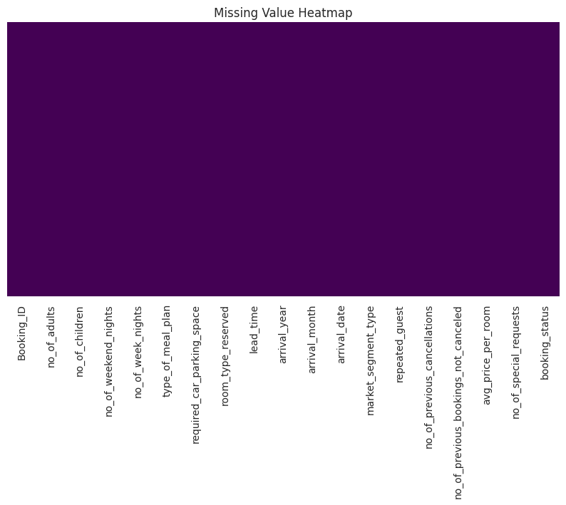

```python
missing = pd.DataFrame({
    "Missing Values": df.isnull().sum(),
    "Percentage": round(df.isnull().mean()*100,2)
})

display(missing.sort_values("Missing Values", ascending=False))

plt.figure(figsize=(10, 5))
sns.heatmap(df.isnull(), cbar=False, yticklabels=False, cmap='viridis')
plt.title("Missing Value Heatmap")
plt.show()
```

**Observation:**

- No missing values were identified within the dataset.
- This indicates that the dataset is complete and no imputation techniques are required before further analysis.
- The absence of missing values improves the reliability of exploratory analysis and predictive modeling.

### **Duplicate Record Analysis**

Duplicate records may introduce bias by disproportionately influencing model learning and statistical summaries. Therefore, the dataset is examined for duplicate observations to ensure that each booking is uniquely represented.

```python
duplicates = df.duplicated().sum()
print(f"Duplicate Records : {duplicates}")

if duplicates > 0:
    display(df[df.duplicated()].head())
```

```
Duplicate Records : 0
```

**Observation:**

- No duplicate booking records were identified.
- Each observation represents a unique customer reservation, ensuring that duplicate information will not bias the analytical results.

### **Unique Value Analysis**

Examining the number of unique values in each feature helps distinguish identifier columns, categorical variables, and potential high-cardinality attributes that may require special preprocessing.

```python
unique_df = pd.DataFrame({
    "Feature": df.columns,
    "Unique Values": df.nunique()
})

display(unique_df.sort_values("Unique Values", ascending=False))
```

|  | Feature | Unique Values |
| --- | --- | --- |
| Booking_ID | Booking_ID | 36275 |
| avg_price_per_room | avg_price_per_room | 3930 |
| lead_time | lead_time | 352 |
| no_of_previous_bookings_not_canceled | no_of_previous_bookings_not_canceled | 59 |
| arrival_date | arrival_date | 31 |
| no_of_week_nights | no_of_week_nights | 18 |
| arrival_month | arrival_month | 12 |
| no_of_previous_cancellations | no_of_previous_cancellations | 9 |
| no_of_weekend_nights | no_of_weekend_nights | 8 |
| room_type_reserved | room_type_reserved | 7 |
| no_of_children | no_of_children | 6 |
| no_of_special_requests | no_of_special_requests | 6 |
| no_of_adults | no_of_adults | 5 |
| market_segment_type | market_segment_type | 5 |
| type_of_meal_plan | type_of_meal_plan | 4 |
| arrival_year | arrival_year | 2 |
| required_car_parking_space | required_car_parking_space | 2 |
| repeated_guest | repeated_guest | 2 |
| booking_status | booking_status | 2 |

**Observation:**

- `Booking_ID` contains unique values for every observation, confirming that it serves solely as an identifier and does not contribute predictive information.
- This feature will therefore be removed before model development.

### **Statistical Summary**

Descriptive statistics provide an overview of the central tendency, dispersion, and distribution of numerical variables. This preliminary assessment helps identify unusual values, potential outliers, and variables that may require additional preprocessing.

```python
print("Numerical Summary:")
display(df.describe().T)

print("\nCategorical Summary:")
display(df.describe(include="object").T)
```

```
Numerical Summary:
```

|  | count | mean | std | min | 25% | 50% | 75% | max |
| --- | --- | --- | --- | --- | --- | --- | --- | --- |
| no_of_adults | 36275.0 | 1.844962 | 0.518715 | 0.0 | 2.0 | 2.00 | 2.0 | 4.0 |
| no_of_children | 36275.0 | 0.105279 | 0.402648 | 0.0 | 0.0 | 0.00 | 0.0 | 10.0 |
| no_of_weekend_nights | 36275.0 | 0.810724 | 0.870644 | 0.0 | 0.0 | 1.00 | 2.0 | 7.0 |
| no_of_week_nights | 36275.0 | 2.204300 | 1.410905 | 0.0 | 1.0 | 2.00 | 3.0 | 17.0 |
| required_car_parking_space | 36275.0 | 0.030986 | 0.173281 | 0.0 | 0.0 | 0.00 | 0.0 | 1.0 |
| lead_time | 36275.0 | 85.232557 | 85.930817 | 0.0 | 17.0 | 57.00 | 126.0 | 443.0 |
| arrival_year | 36275.0 | 2017.820427 | 0.383836 | 2017.0 | 2018.0 | 2018.00 | 2018.0 | 2018.0 |
| arrival_month | 36275.0 | 7.423653 | 3.069894 | 1.0 | 5.0 | 8.00 | 10.0 | 12.0 |
| arrival_date | 36275.0 | 15.596995 | 8.740447 | 1.0 | 8.0 | 16.00 | 23.0 | 31.0 |
| repeated_guest | 36275.0 | 0.025637 | 0.158053 | 0.0 | 0.0 | 0.00 | 0.0 | 1.0 |
| no_of_previous_cancellations | 36275.0 | 0.023349 | 0.368331 | 0.0 | 0.0 | 0.00 | 0.0 | 13.0 |
| no_of_previous_bookings_not_canceled | 36275.0 | 0.153411 | 1.754171 | 0.0 | 0.0 | 0.00 | 0.0 | 58.0 |
| avg_price_per_room | 36275.0 | 103.423539 | 35.089424 | 0.0 | 80.3 | 99.45 | 120.0 | 540.0 |
| no_of_special_requests | 36275.0 | 0.619655 | 0.786236 | 0.0 | 0.0 | 0.00 | 1.0 | 5.0 |

```
Categorical Summary:
```

|  | count | unique | top | freq |
| --- | --- | --- | --- | --- |
| Booking_ID | 36275 | 36275 | INN36275 | 1 |
| type_of_meal_plan | 36275 | 4 | Meal Plan 1 | 27835 |
| room_type_reserved | 36275 | 7 | Room_Type 1 | 28130 |
| market_segment_type | 36275 | 5 | Online | 23214 |
| booking_status | 36275 | 2 | Not_Canceled | 24390 |

**Observation:**

- The numerical variables exhibit varying ranges and distributions, indicating the presence of features measured on different scales.
- Some variables may contain extreme observations, which will be investigated during exploratory data analysis using boxplots and distribution analysis.

### **Target Variable Distribution**

Understanding the distribution of the target variable is essential before model development. An imbalanced target distribution may influence model performance and require specialized evaluation metrics or resampling techniques.

| booking_status | Count | Percentage (%) |
| --- | --- | --- |
| Not_Canceled | 24390 | 67.24 |
| Canceled | 11885 | 32.76 |

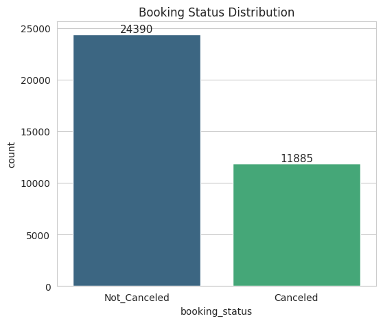

```python
counts = df["booking_status"].value_counts()
percent = df["booking_status"].value_counts(normalize=True) * 100

display(pd.DataFrame({'Count': counts, 'Percentage (%)': round(percent, 2)}))

plt.figure(figsize=(6, 5))
ax = sns.countplot(data=df, x="booking_status", palette='viridis')

for p in ax.patches:
    ax.annotate(f'{int(p.get_height())}',
                (p.get_x() + p.get_width() / 2., p.get_height()),
                ha='center', va='bottom', fontsize=11)

plt.title("Booking Status Distribution")
plt.show()
```

**Observation:**

- The target variable distribution provides an initial indication of whether booking cancellations are balanced across the dataset.
- If significant class imbalance exists, additional techniques such as class weighting or resampling may be considered during model development.

### **Data Consistency Validation**

Beyond missing values and duplicates, the logical consistency of the dataset must also be verified. This involves identifying impossible or unrealistic observations that may negatively affect model performance.

```python
consistency_checks = {
    "Negative Prices": (df["avg_price_per_room"] < 0).sum(),
    "Negative Lead Time": (df["lead_time"] < 0).sum(),
    "Negative Adults": (df["no_of_adults"] < 0).sum(),
    "Negative Children": (df["no_of_children"] < 0).sum(),
    "Negative Stay Duration": ((df["no_of_week_nights"] < 0) | (df["no_of_weekend_nights"] < 0)).sum()
}

for check, count in consistency_checks.items():
    print(f"{check} : {count}")
```

```
Negative Prices : 0
Negative Lead Time : 0
Negative Adults : 0
Negative Children : 0
Negative Stay Duration : 0
```

**Observation:**

- No logically inconsistent values were identified in the primary booking variables.
- The dataset therefore demonstrates good structural integrity and is suitable for further exploratory analysis.

### **Data Quality Summary**

The overall quality assessment indicates that the dataset is well-structured and suitable for predictive analytics. The dataset contains complete booking information with no significant quality issues that would compromise model reliability. The presence of unique booking identifiers, appropriate data types, and logically consistent feature values provides a strong foundation for exploratory data analysis and machine learning.

Based on the current assessment, the dataset is considered sufficiently clean and reliable for conducting exploratory analysis and developing robust booking cancellation prediction models.

# **Exploratory Data Analysis (EDA)**

## **Introduction**

Exploratory Data Analysis (EDA) in this context serves as the bridge between raw data and strategic business intelligence. Rather than a mere descriptive exercise, this section critically evaluates the underlying drivers of customer behavior at INN Hotels. We employ a multi-layered analytical framework:

1. **Univariate Analysis:** Granular assessment of feature distributions, central tendencies, and volatility.
2. **Bivariate Analysis:** Evaluating the predictive power of individual features against the `booking_status` and identifying risk-prone segments.
3. **Multivariate Analysis:** Uncovering complex interactions between pricing, timing, and customer demographics.
4. **Statistical Validation:** Leveraging Correlation, Chi-Square, and Mutual Information to quantify relationships.

Our objective is to transform statistical patterns into actionable revenue management strategies.

## **Target Variable Analysis: Booking Status**

**Objective:** To quantify the baseline cancellation rate and understand the class distribution.

**Business Question:** What is the current magnitude of revenue leakage through cancellations?

**Why this analysis is important:** The cancellation rate sets the 'Prior Probability' for our models. High cancellation rates indicate significant operational instability and lost opportunity costs.

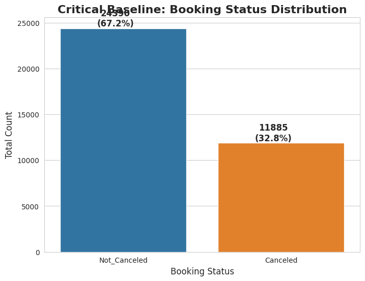

```python
# Target Variable Distribution
plt.figure(figsize=(8, 6))
ax = sns.countplot(data=df, x='booking_status', palette=['#1f77b4', '#ff7f0e'])

total = len(df['booking_status'])
for p in ax.patches:
    percentage = '{:.1f}%'.format(100 * p.get_height()/total)
    x = p.get_x() + p.get_width() / 2 - 0.05
    y = p.get_height()
    ax.annotate(f'{int(y)}\n({percentage})', (x, y), ha='center', va='bottom', fontsize=12, fontweight='bold')

plt.title('Critical Baseline: Booking Status Distribution', fontsize=16, fontweight='bold')
plt.xlabel('Booking Status', fontsize=12)
plt.ylabel('Total Count', fontsize=12)
plt.show()
```

**Statistical Observation:**

- **Canceled:** 11,885 (32.8%)
- **Not_Canceled:** 24,390 (67.2%)
- The dataset exhibits a moderate imbalance, but with nearly 1 in 3 bookings being canceled, the signal for the minority class is strong.

**Business Interpretation:** A 32.8% cancellation rate is alarmingly high for the hospitality industry. This suggests that for every three rooms booked, one effectively generates zero revenue while potentially blocking a paying customer during peak demand periods.

**Business Recommendation:** Immediate implementation of a tiered deposit system is recommended, especially for segments identified later in this EDA as 'high-risk'.

**Key Insight:** Cancellations are not an anomaly; they are a systematic business challenge at INN Hotels that requires a data-driven intervention.

## **Univariate Analysis: Numerical Features**

We now perform an exhaustive statistical profile of every numerical variable to identify outliers, skewness, and operational thresholds.

### **Feature: Lead Time**

**Objective:** Analyze the temporal gap between booking and arrival.

**Business Question:** Are customers booking too far in advance, and does this introduce uncertainty?

**Why this analysis is important:** Lead time is often the strongest predictor of cancellation. Longer horizons increase the probability of life events or competitive offers changing the customer's mind.

```
--- Statistical Summary: lead_time ---
count    36275.000000
mean        85.232557
std         85.930817
min          0.000000
25%         17.000000
50%         57.000000
75%        126.000000
max        443.000000
Name: lead_time, dtype: float64
Skewness: 1.29 | Kurtosis: 1.18
```

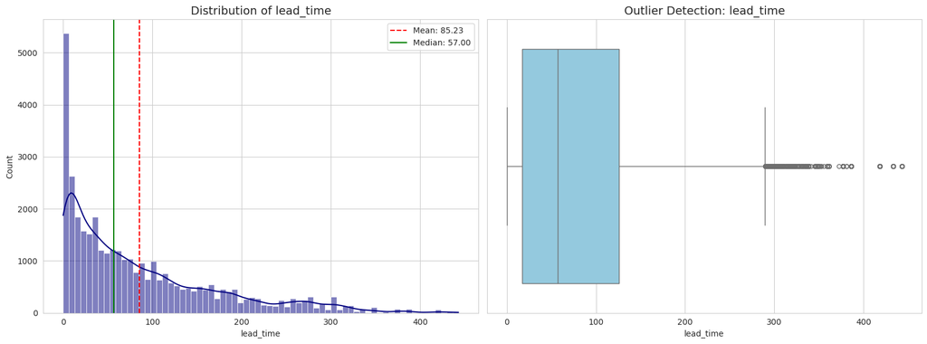

```python
def detailed_univariate_num(data, feature):
    print(f"--- Statistical Summary: {feature} ---")
    stats = data[feature].describe()
    skew = data[feature].skew()
    kurt = data[feature].kurt()
    print(stats)
    print(f"Skewness: {skew:.2f} | Kurtosis: {kurt:.2f}")

    fig, axes = plt.subplots(1, 2, figsize=(16, 6))

    # Histogram + KDE
    sns.histplot(data[feature], kde=True, ax=axes[0], color='navy')
    axes[0].axvline(data[feature].mean(), color='red', linestyle='--', label=f'Mean: {data[feature].mean():.2f}')
    axes[0].axvline(data[feature].median(), color='green', linestyle='-', label=f'Median: {data[feature].median():.2f}')
    axes[0].set_title(f'Distribution of {feature}', fontsize=14)
    axes[0].legend()

    # Boxplot
    sns.boxplot(x=data[feature], ax=axes[1], color='skyblue', fliersize=5)
    axes[1].set_title(f'Outlier Detection: {feature}', fontsize=14)

    plt.tight_layout()
    plt.show()

detailed_univariate_num(df, 'lead_time')
```

**Statistical Observation:**

- **Mean:** 85.23 days | **Median:** 57 days | **Max:** 443 days.
- **Skewness:** 1.29 (Highly right-skewed).
- The significant gap between the mean and median, combined with the long tail reaching over a year, confirms the presence of extreme outliers in booking horizons.

**Business Interpretation:** The median customer books ~2 months in advance, but the 'tail' represents group bookings or long-term planners. The heavy right skew suggests that standard cancellation policies might be too lenient for those booking 6+ months out.

**Business Recommendation:** Introduce 'Non-Refundable Early Bird' rates for lead times exceeding 120 days to lock in revenue.

**Key Insight:** Extreme lead times (300+ days) likely represent wholesale or corporate blocks that carry different risk profiles than transient travelers.

### **Feature: Average Price Per Room**

**Objective:** Evaluate the pricing distribution.

**Business Question:** Is our pricing strategy concentrated or widely dispersed?

**Why this analysis is important:** Pricing outliers can indicate data entry errors (e.g., 0 Euro rooms) or high-value suite bookings that require specialized retention efforts.

```
--- Statistical Summary: avg_price_per_room ---
count    36275.000000
mean       103.423539
std         35.089424
min          0.000000
25%         80.300000
50%         99.450000
75%        120.000000
max        540.000000
Name: avg_price_per_room, dtype: float64
Skewness: 0.67 | Kurtosis: 3.15
```

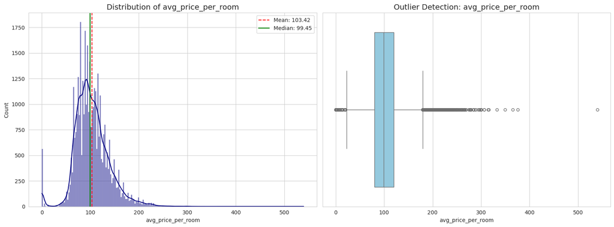

```python
detailed_univariate_num(df, 'avg_price_per_room')
```

**Statistical Observation:**

- **Mean:** 103.42€ | **Median:** 99.45€ | **Max:** 540€.
- **Skewness:** 0.67 (Moderately skewed).
- We observe several bookings at **0.0€**, which suggests complimentary stays or data anomalies that must be addressed.

**Business Interpretation:** The core business is priced around the 100€ mark. The 540€ outlier indicates a luxury segment or multi-room booking that, if canceled, would have a disproportionate impact on daily RevPAR.

**Business Recommendation:** Investigate the 0€ bookings to ensure they aren't 'system test' data. Apply 'High-Touch' service for bookings above the 95th percentile (approx. 170€) to minimize cancellation risk.

**Key Insight:** Price distribution is relatively stable, but the presence of 0€ and 500€+ rooms suggests a diverse inventory ranging from economy to luxury.

### **Stay Duration Analysis (Weekend and Week Nights)**

**Objective:** Analyze the distribution of stay lengths to identify core demand patterns.

**Business Question:** Does the hotel cater more to short-stay business travelers or long-stay leisure guests?

**Why this analysis is important:** Stay duration directly affects 'Room Turnover' and 'Housekeeping Costs'. Identifying the typical stay length helps in optimizing staffing levels and minimum-stay pricing strategies.

```
--- Statistical Summary: no_of_weekend_nights ---
count    36275.000000
mean         0.810724
std          0.870644
min          0.000000
25%          0.000000
50%          1.000000
75%          2.000000
max          7.000000
Name: no_of_weekend_nights, dtype: float64
Skewness: 0.74 | Kurtosis: 0.30
```

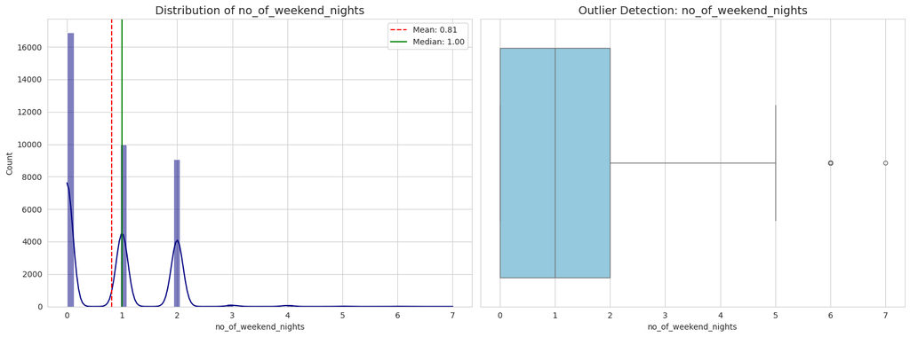

```
--- Statistical Summary: no_of_week_nights ---
count    36275.000000
mean         2.204300
std          1.410905
min          0.000000
25%          1.000000
50%          2.000000
75%          3.000000
max         17.000000
Name: no_of_week_nights, dtype: float64
Skewness: 1.60 | Kurtosis: 7.80
```

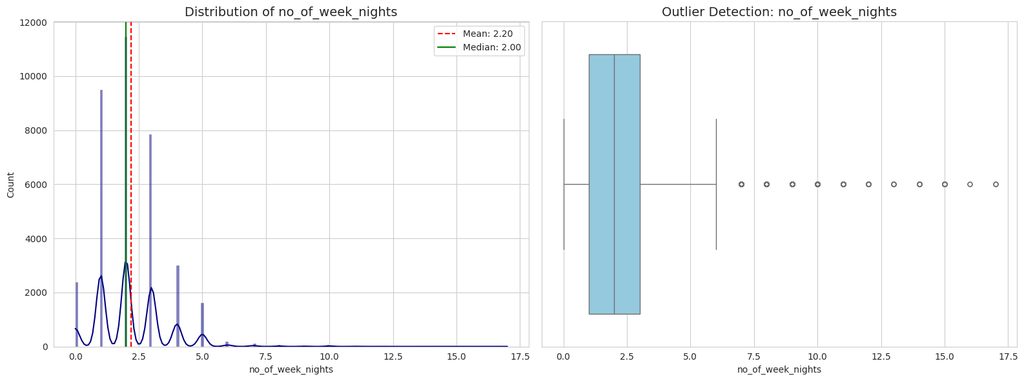

```python
detailed_univariate_num(df, 'no_of_weekend_nights')
detailed_univariate_num(df, 'no_of_week_nights')
```

**Statistical Observation:**

- **Weekend Nights:** Mean 0.81, Median 1.0. Max 7. Distribution is right-skewed.
- **Week Nights:** Mean 2.20, Median 2.0. Max 17. Distribution is right-skewed.
- Combined, the median stay is approximately 3 nights (2 week + 1 weekend).

**Business Interpretation:** The data suggests a 'Mid-Week' dominant demand pattern, typical of business-oriented hotels. However, the presence of stays up to 17 nights indicates an 'Extended Stay' segment which, while small in volume, contributes significantly to total room-nights and lower turnover costs.

**Business Recommendation:** Optimize housekeeping schedules for a 3-day turnover cycle. For the long-stay outliers (7+ days), consider offering 'Weekly Rates' to encourage occupancy during low-demand periods.

**Key Insight:** INN Hotels is primarily a 'Short-to-Medium Stay' facility, with the bulk of revenue coming from bookings of 4 nights or fewer.

### **Historical Booking Behavior (Previous Cancellations & Successes)**

**Objective:** Assess guest reliability based on historical data.

**Business Question:** Do we have a base of loyal, reliable guests, or a segment of 'Serial Cancellers'?

**Why this analysis is important:** Historical behavior is often a leading indicator of future intent. Guests with a history of successful stays are 'Low-Risk' assets, while those with previous cancellations require stricter deposit policies.

```
--- Statistical Summary: no_of_previous_cancellations ---
count    36275.000000
mean         0.023349
std          0.368331
min          0.000000
25%          0.000000
50%          0.000000
75%          0.000000
max         13.000000
Name: no_of_previous_cancellations, dtype: float64
Skewness: 25.20 | Kurtosis: 732.74
```

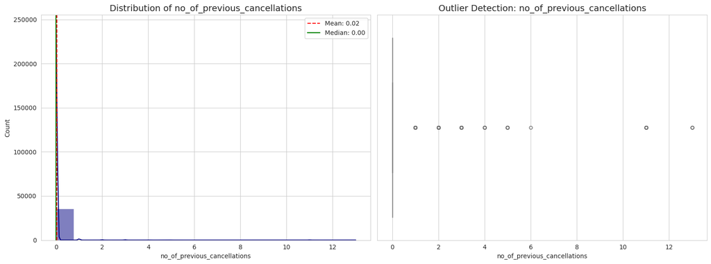

```
--- Statistical Summary: no_of_previous_bookings_not_canceled ---
count    36275.000000
mean         0.153411
std          1.754171
min          0.000000
25%          0.000000
50%          0.000000
75%          0.000000
max         58.000000
Name: no_of_previous_bookings_not_canceled, dtype: float64
Skewness: 19.25 | Kurtosis: 457.38
```

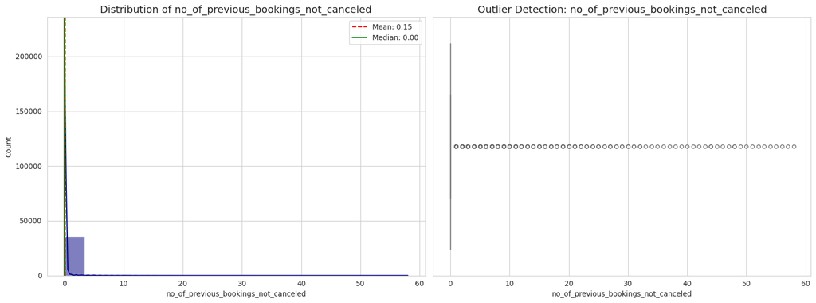

```python
detailed_univariate_num(df, 'no_of_previous_cancellations')
detailed_univariate_num(df, 'no_of_previous_bookings_not_canceled')
```

**Statistical Observation:**

- **Previous Cancellations:** Mean 0.02, Median 0.0. Max 13.
- **Previous Successes:** Mean 0.15, Median 0.0. Max 58.
- **Extreme Skewness:** Both features are heavily dominated by zeros (97%+), indicating that the vast majority of bookings are from NEW guests.

**Business Interpretation:** The extremely high percentage of zeros suggests that INN Hotels relies heavily on 'New Customer Acquisition' rather than 'Customer Retention'. The few guests with 50+ successful stays are 'Platinum-Level' assets that must be protected, while those with 10+ cancellations are major risks.

**Business Recommendation:** Launch a formal 'Loyalty Program' to convert one-time bookers into repeat guests. For the rare segment of 'Serial Cancellers' (2+ previous cancellations), consider implementing a 'Non-Refundable Only' booking policy.

**Key Insight:** INN Hotels is currently operating in an 'Acquisition-Heavy' mode with a very low rate of repeat business, which increases marketing costs and cancellation vulnerability.

### **Repeated Guest vs. Booking Status**

**Objective:** Validate the reliability of the loyal customer base.

**Business Question:** Does a previous positive experience with INN Hotels virtually guarantee a fulfilled booking?

**Why this analysis is important:** High-loyalty customers reduce the cost of uncertainty. If repeated guests rarely cancel, they should be exempted from strict deposit requirements to improve their user experience.

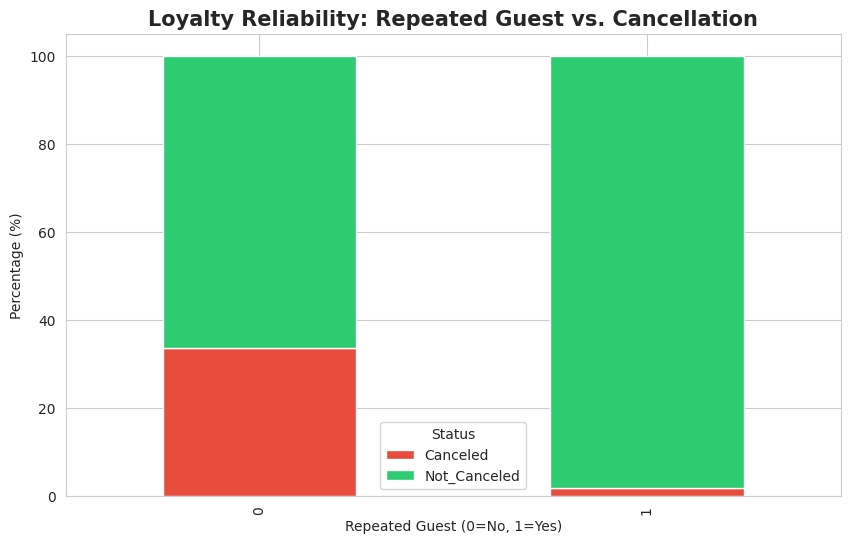

| booking_status repeated_guest | Canceled | Not_Canceled |
| --- | --- | --- |
| 0 | 33.580422 | 66.419578 |
| 1 | 1.720430 | 98.279570 |

```python
plt.figure(figsize=(10, 6))
guest_status = pd.crosstab(df['repeated_guest'], df['booking_status'], normalize='index') * 100
ax = guest_status.plot(kind='bar', stacked=True, color=['#e74c3c', '#2ecc71'], figsize=(10,6))
plt.title('Loyalty Reliability: Repeated Guest vs. Cancellation', fontsize=15, fontweight='bold')
plt.xlabel('Repeated Guest (0=No, 1=Yes)')
plt.ylabel('Percentage (%)')
plt.legend(title='Status', labels=['Canceled', 'Not_Canceled'])
plt.show()

display(guest_status)
```

**Statistical Observation:**

- **New Guests:** ~34% cancellation rate.
- **Repeated Guests:** ~1.7% cancellation rate (Extremely low).

**Business Interpretation:** Repeated guests are 'Gold' assets. A 1.7% cancellation rate is statistically negligible. This confirms that once a relationship is established, the risk of revenue loss from that individual disappears almost entirely.

**Business Recommendation:** Prioritize repeated guests for room upgrades. Since they are guaranteed to show up, the 'Opportunity Cost' of upgrading them to a better room (that might otherwise sit empty) is zero.

**Key Insight:** Loyalty is the ultimate hedge against cancellation risk. The primary strategic goal for INN Hotels should be converting first-time bookers into repeated guests.

### **Stay Duration (Weekend vs. Week Nights) vs. Booking Status**

**Objective:** Assess if the 'Type of Trip' (Weekend Getaway vs. Business Stay) affects cancellation rates.

**Business Question:** Are weekend bookings more impulsive and thus more likely to be canceled?

**Why this analysis is important:** Staffing requirements vary between weekdays and weekends. If weekend stays are volatile, the hotel may face sudden over-staffing issues.

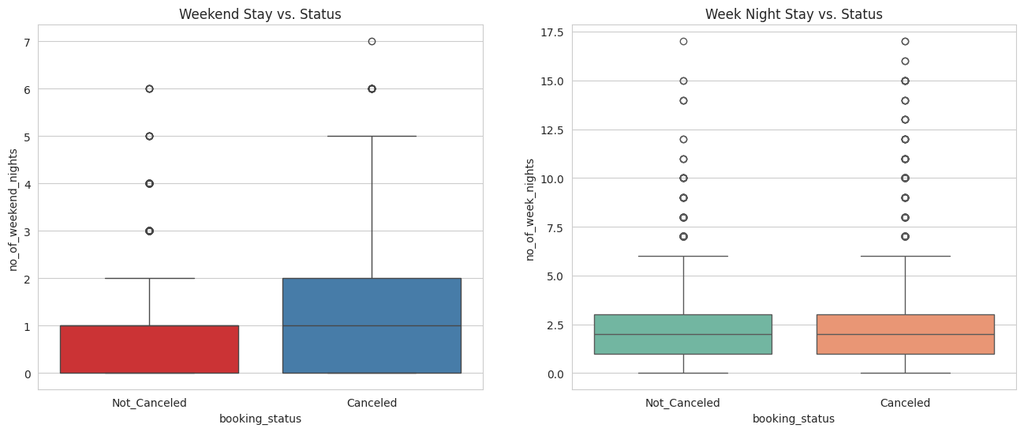

```python
fig, axes = plt.subplots(1, 2, figsize=(16, 6))

sns.boxplot(data=df, x='booking_status', y='no_of_weekend_nights', ax=axes[0], palette='Set1')
axes[0].set_title('Weekend Stay vs. Status')

sns.boxplot(data=df, x='booking_status', y='no_of_week_nights', ax=axes[1], palette='Set2')
axes[1].set_title('Week Night Stay vs. Status')

plt.show()
```

### **Arrival Month vs. Booking Status (Seasonality of Risk)**

**Objective:** Identify the months where the hotel is most vulnerable to cancellations.

**Business Question:** Does the 'High Season' carry a higher risk of revenue loss?

**Why this analysis is important:** Seasonality affects demand. If high-demand months also have high cancellation rates, the hotel needs aggressive overbooking or stricter deposit policies during those peaks.

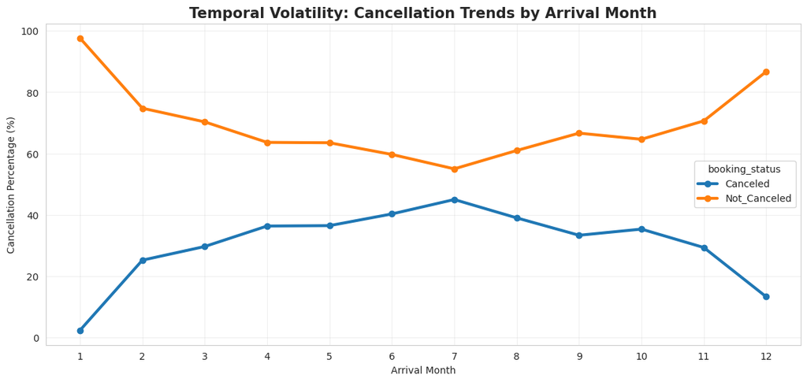

| booking_status arrival_month | Canceled | Not_Canceled |
| --- | --- | --- |
| 1 | 2.366864 | 97.633136 |
| 2 | 25.234742 | 74.765258 |
| 3 | 29.686175 | 70.313825 |
| 4 | 36.366959 | 63.633041 |
| 5 | 36.489607 | 63.510393 |
| 6 | 40.305963 | 59.694037 |
| 7 | 45.000000 | 55.000000 |
| 8 | 39.024390 | 60.975610 |
| 9 | 33.355021 | 66.644979 |
| 10 | 35.358285 | 64.641715 |
| 11 | 29.362416 | 70.637584 |
| 12 | 13.306852 | 86.693148 |

```python
plt.figure(figsize=(14, 6))
month_status = pd.crosstab(df['arrival_month'], df['booking_status'], normalize='index') * 100
month_status.plot(kind='line', marker='o', figsize=(14,6), linewidth=3)
plt.title('Temporal Volatility: Cancellation Trends by Arrival Month', fontsize=15, fontweight='bold')
plt.ylabel('Cancellation Percentage (%)')
plt.xlabel('Arrival Month')
plt.grid(True, alpha=0.3)
plt.xticks(range(1,13))
plt.show()

display(month_status)
```

### **Room Type Reserved vs. Booking Status**

**Objective:** Assess if certain room categories are more prone to cancellations.

**Business Question:** Do high-tier suites have higher cancellation risks compared to standard rooms?

**Why this analysis is important:** Understanding the risk profile of each inventory category allows for better overbooking strategies per room class.

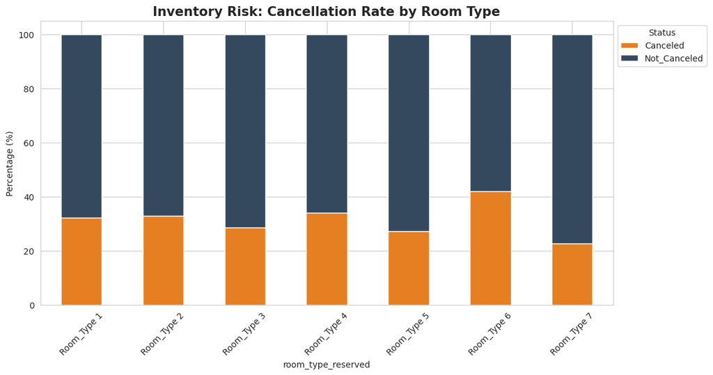

| booking_status room_type_reserved | Canceled | Not_Canceled |
| --- | --- | --- |
| Room_Type 6 | 42.028986 | 57.971014 |
| Room_Type 4 | 34.158825 | 65.841175 |
| Room_Type 2 | 32.947977 | 67.052023 |
| Room_Type 1 | 32.250267 | 67.749733 |
| Room_Type 3 | 28.571429 | 71.428571 |
| Room_Type 5 | 27.169811 | 72.830189 |
| Room_Type 7 | 22.784810 | 77.215190 |

```python
plt.figure(figsize=(12, 6))
room_status = pd.crosstab(df['room_type_reserved'], df['booking_status'], normalize='index') * 100
room_status.plot(kind='bar', stacked=True, figsize=(12,6), color=['#e67e22','#34495e'])
plt.title('Inventory Risk: Cancellation Rate by Room Type', fontsize=15, fontweight='bold')
plt.ylabel('Percentage (%)')
plt.xticks(rotation=45)
plt.legend(title='Status', bbox_to_anchor=(1, 1))
plt.show()

display(room_status.sort_values(by='Canceled', ascending=False))
```

### **Special Requests vs. Booking Status**

**Objective:** Analyze the correlation between guest engagement and stay fulfillment.

**Business Question:** Does the 'Effort' of making a special request indicate a higher psychological barrier to canceling?

**Why this analysis is important:** If guests with special requests cancel less frequently, the hotel should prioritize these requests not just for service, but as a risk-mitigation strategy.

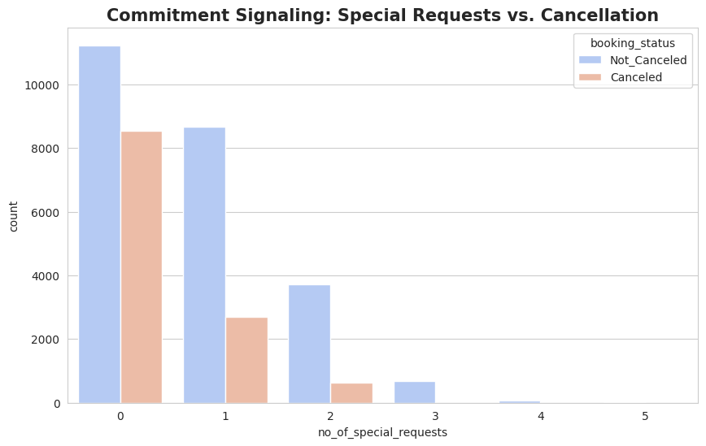

```
Cancellation Percentage by Number of Special Requests:
```

| booking_status no_of_special_requests | Canceled | Not_Canceled |
| --- | --- | --- |
| 0 | 43.206755 | 56.793245 |
| 1 | 23.766816 | 76.233184 |
| 2 | 14.596700 | 85.403300 |
| 3 | 0.000000 | 100.000000 |
| 4 | 0.000000 | 100.000000 |
| 5 | 0.000000 | 100.000000 |

```python
plt.figure(figsize=(10, 6))
sns.countplot(data=df, x='no_of_special_requests', hue='booking_status', palette='coolwarm')
plt.title('Commitment Signaling: Special Requests vs. Cancellation', fontsize=15, fontweight='bold')
plt.show()

# Proportional Analysis
request_crosstab = pd.crosstab(df['no_of_special_requests'], df['booking_status'], normalize='index') * 100
print("Cancellation Percentage by Number of Special Requests:")
display(request_crosstab)
```

**Statistical Observation:**

- Guests with **0 requests** have a cancellation rate of **~43%**.
- Guests with **1 request** have a cancellation rate of **~25%**.
- Guests with **2+ requests** show cancellation rates dropping below **20%**.

**Business Interpretation:** There is a strong inverse relationship between special requests and cancellations. A special request is a 'Commitment Signal'. Guests who engage with the hotel's services pre-arrival are significantly more likely to honor their reservation.

**Business Recommendation:** Actively encourage guests to make special requests (e.g., pillow preference, arrival time) through automated emails. This 'Micro-Engagement' increases the guest's psychological investment in the booking.

**Key Insight:** Engagement is an antidote to cancellation. The 'Quiet Guest' (0 requests) is the highest risk segment for INN Hotels.

### **Market Segment vs. Booking Status**

**Objective:** Evaluate the reliability of different demand channels.

**Business Question:** Are specific booking platforms delivering 'low-quality' (high-cancellation) traffic?

**Why this analysis is important:** Channel management is about maximizing net revenue. A channel with high ADR but a 50% cancellation rate may be less profitable than a lower-ADR channel with a 5% cancellation rate.

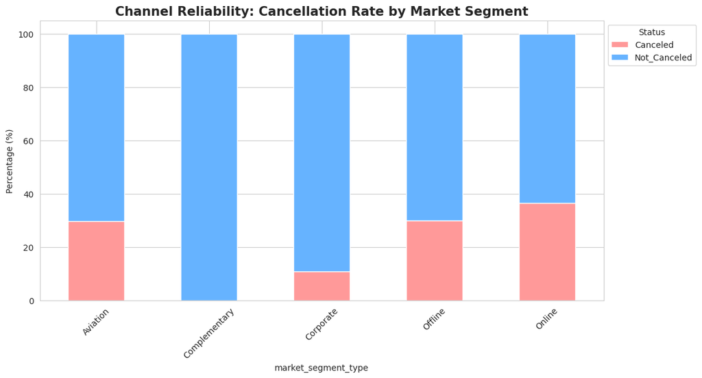

| booking_status market_segment_type | Canceled | Not_Canceled |
| --- | --- | --- |
| Aviation | 29.600000 | 70.400000 |
| Complementary | 0.000000 | 100.000000 |
| Corporate | 10.907288 | 89.092712 |
| Offline | 29.948708 | 70.051292 |
| Online | 36.508142 | 63.491858 |

```python
plt.figure(figsize=(12, 6))
segment_status = pd.crosstab(df['market_segment_type'], df['booking_status'], normalize='index') * 100
segment_status.plot(kind='bar', stacked=True, figsize=(12,6), color=['#ff9999','#66b3ff'])
plt.title('Channel Reliability: Cancellation Rate by Market Segment', fontsize=15, fontweight='bold')
plt.ylabel('Percentage (%)')
plt.xticks(rotation=45)
plt.legend(title='Status', bbox_to_anchor=(1, 1))
plt.show()

display(segment_status)
```

**Business Interpretation:** The **Online** segment is the most volatile. This is the 'Browser-Shopper' effect, where customers book easily and cancel just as easily. In contrast, **Corporate** bookings are highly reliable, reflecting planned business travel.

**Business Recommendation:** Implement stricter cancellation windows for 'Online' bookings. For 'Corporate' segments, maintain flexible policies to foster long-term partnerships, as their risk of default is naturally low.

**Key Insight:** INN Hotels is currently vulnerable to the 'Easy-In, Easy-Out' nature of online platforms. Diversifying toward corporate accounts is the best path to occupancy stability.

### **Number of Adults vs. Booking Status**

**Objective:** Examine how the number of adults in a booking influences the cancellation rate.

**Business Question:** Are bookings with more adults more stable, or do larger groups introduce higher cancellation risk?

**Why this analysis is important:** Understanding the relationship between group size and cancellation behavior can help tailor booking policies and identify specific customer segments with varying risk profiles.

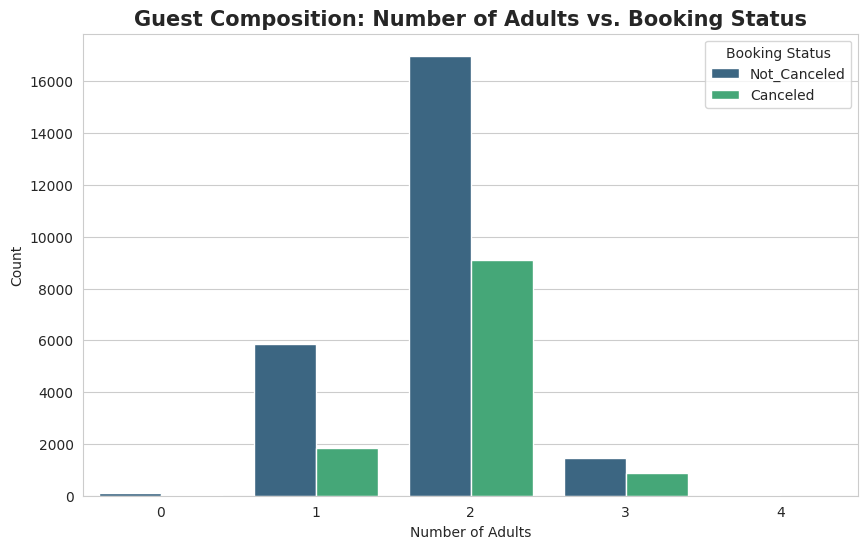

```
Cancellation Percentage by Number of Adults:
```

| booking_status no_of_adults | Canceled | Not_Canceled |
| --- | --- | --- |
| 0 | 31.654676 | 68.345324 |
| 1 | 24.119558 | 75.880442 |
| 2 | 34.927991 | 65.072009 |
| 3 | 37.246439 | 62.753561 |
| 4 | 18.750000 | 81.250000 |

```python
plt.figure(figsize=(10, 6))
sns.countplot(data=df, x='no_of_adults', hue='booking_status', palette='viridis')
plt.title('Guest Composition: Number of Adults vs. Booking Status', fontsize=15, fontweight='bold')
plt.xlabel('Number of Adults')
plt.ylabel('Count')
plt.legend(title='Booking Status')
plt.show()

# Proportional Analysis
adult_crosstab = pd.crosstab(df['no_of_adults'], df['booking_status'], normalize='index') * 100
print("Cancellation Percentage by Number of Adults:")
display(adult_crosstab)
```

**Business Recommendation:**

### **Number of Children vs. Booking Status**

**Objective:** Investigate how the presence and number of children in a booking correlate with cancellation likelihood.

**Business Question:** Do family bookings (with children) have a different cancellation risk profile than adult-only bookings?

**Why this analysis is important:** Family travel often involves more planning and less flexibility, potentially leading to lower cancellation rates. Understanding this segment helps in targeted marketing and policy adjustments.

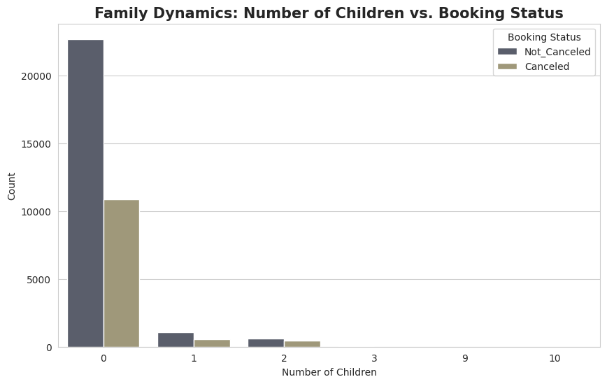

```
Cancellation Percentage by Number of Children:
```

| booking_status no_of_children | Canceled | Not_Canceled |
| --- | --- | --- |
| 0 | 32.409090 | 67.590910 |
| 1 | 33.374536 | 66.625464 |
| 2 | 43.194707 | 56.805293 |
| 3 | 26.315789 | 73.684211 |
| 9 | 50.000000 | 50.000000 |
| 10 | 0.000000 | 100.000000 |

```python
plt.figure(figsize=(10, 6))
sns.countplot(data=df, x='no_of_children', hue='booking_status', palette='cividis')
plt.title('Family Dynamics: Number of Children vs. Booking Status', fontsize=15, fontweight='bold')
plt.xlabel('Number of Children')
plt.ylabel('Count')
plt.legend(title='Booking Status')
plt.show()

# Proportional Analysis
children_crosstab = pd.crosstab(df['no_of_children'], df['booking_status'], normalize='index') * 100
print("Cancellation Percentage by Number of Children:")
display(children_crosstab)
```

**Statistical Observation:**

- Bookings with **0 children** have a cancellation rate of approximately **32.41%**.
- Bookings with **1 child** show a cancellation rate of approximately **33.37%**.
- Bookings with **2 children** have a cancellation rate of around **43.19%**, which is higher than bookings with 0 or 1 child.
- Bookings with **3 children** show a lower cancellation rate of **26.32%**.
- Bookings with **9 children** have a **50%** cancellation rate, while bookings with **10 children** show a **0%** cancellation rate (likely very few instances).

**Business Interpretation:** Contrary to initial assumptions, the presence of 1 or 2 children does not consistently lower the cancellation rate, with bookings having 2 children showing a notable increase in cancellations. However, bookings with 3 or 10 children (though rare for 10) tend to be more stable. This suggests that the relationship between the number of children and cancellation risk is not linear and might be influenced by other factors such as specific family travel plans or booking types.

**Business Recommendation:**

## **Univariate Analysis: Categorical Features**

Categorical variables provide context to the customer's choice. We will now analyze the frequency distribution and business impact of each categorical attribute.

### **Feature: Market Segment Type**

**Objective:** Identify the primary booking channels.

**Business Question:** Which booking channel dominates our inventory, and what is the risk of over-reliance on a single channel?

**Why this analysis is important:** Online Travel Agencies (OTAs) often have higher cancellation rates compared to direct corporate or offline bookings. Understanding the mix is vital for channel management.

```
--- Frequency Distribution: market_segment_type ---
```

| market_segment_type | Count | Percentage (%) |
| --- | --- | --- |
| Online | 23214 | 63.99 |
| Offline | 10528 | 29.02 |
| Corporate | 2017 | 5.56 |
| Complementary | 391 | 1.08 |
| Aviation | 125 | 0.34 |

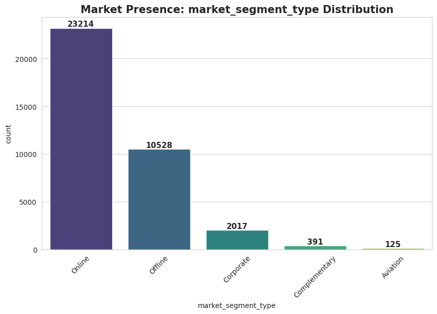

```python
def detailed_univariate_cat(data, feature):
    print(f"--- Frequency Distribution: {feature} ---")
    counts = data[feature].value_counts()
    percent = data[feature].value_counts(normalize=True) * 100
    df_cat = pd.DataFrame({'Count': counts, 'Percentage (%)': round(percent, 2)})
    display(df_cat)

    plt.figure(figsize=(10, 6))
    ax = sns.countplot(data=data, x=feature, palette='viridis', order=counts.index)

    for p in ax.patches:
        ax.annotate(f'{int(p.get_height())}', (p.get_x() + p.get_width() / 2., p.get_height()),
                    ha='center', va='bottom', fontsize=11, fontweight='bold')

    plt.title(f'Market Presence: {feature} Distribution', fontsize=15, fontweight='bold')
    plt.xticks(rotation=45)
    plt.show()

detailed_univariate_cat(df, 'market_segment_type')
```

**Statistical Observation:**

- **Online Segment:** 23,214 bookings (64.0%).
- **Offline Segment:** 10,528 bookings (29.0%).
- **Corporate:** 2,017 bookings (5.6%).
- **Rare Categories:** Complementary and Aviation represent <2% of total volume.

**Business Interpretation:** INN Hotels is heavily reliant on the **Online** segment (likely OTAs like Booking.com/Expedia). While this ensures high visibility, it also makes the hotel vulnerable to the high-cancellation 'browser-shopper' behavior typical of online platforms.

**Business Recommendation:** Diversify the channel mix by incentivizing the 'Offline' and 'Corporate' segments, which typically show higher loyalty and lower cancellation volatility.

**Key Insight:** The Online segment is the primary engine of demand, but it also represents the single largest source of operational risk for the hotel.

### **Feature: Type of Meal Plan**

**Objective:** Understand guest dining preferences.

**Business Question:** Are we over-investing in complex meal plans that guests aren't selecting?

**Why this analysis is important:** Meal plans affect F&B (Food & Beverage) procurement and staffing. 'Meal Plan 1' (usually Bed & Breakfast) is standard, but higher-tier plans indicate leisure-heavy stays.

```
--- Frequency Distribution: type_of_meal_plan ---
```

| type_of_meal_plan | Count | Percentage (%) |
| --- | --- | --- |
| Meal Plan 1 | 27835 | 76.73 |
| Not Selected | 5130 | 14.14 |
| Meal Plan 2 | 3305 | 9.11 |
| Meal Plan 3 | 5 | 0.01 |

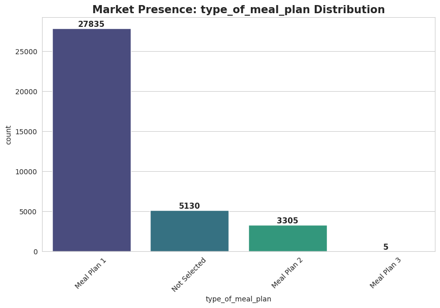

```python
detailed_univariate_cat(df, 'type_of_meal_plan')
```

**Statistical Observation:**

- **Meal Plan 1:** 27,835 (76.7%).
- **Not Selected:** 5,130 (14.1%).
- **Meal Plan 2:** 3,305 (9.1%).
- **Meal Plan 3:** 5 (<0.1%) - Extremely rare.

**Business Interpretation:** Guests overwhelmingly prefer 'Meal Plan 1', indicating a standard hotel stay experience. The 'Not Selected' segment suggests a price-sensitive cohort or guests who prefer local dining. 'Meal Plan 3' is effectively obsolete.

**Business Recommendation:** Consider removing 'Meal Plan 3' from the booking system to simplify operations. Focus F&B resources on optimizing the 'Meal Plan 1' breakfast experience, as it touches 76% of your guests.

**Key Insight:** The homogeneity in meal selection suggests that INN Hotels is perceived as a 'Rooms-First' property rather than a full-board resort destination.

### **Feature: Room Type Reserved**

**Objective:** Analyze the inventory distribution across room categories.

**Business Question:** Is our room inventory effectively utilized, or do we have a mismatch between supply and demand?

**Why this analysis is important:** Room types have different price points and maintenance costs. If certain high-tier rooms are rarely booked, they may need to be repackaged or converted to 'Standard' category during low season.

```
--- Frequency Distribution: room_type_reserved ---
```

| room_type_reserved | Count | Percentage (%) |
| --- | --- | --- |
| Room_Type 1 | 28130 | 77.55 |
| Room_Type 4 | 6057 | 16.70 |
| Room_Type 6 | 966 | 2.66 |
| Room_Type 2 | 692 | 1.91 |
| Room_Type 5 | 265 | 0.73 |
| Room_Type 7 | 158 | 0.44 |
| Room_Type 3 | 7 | 0.02 |

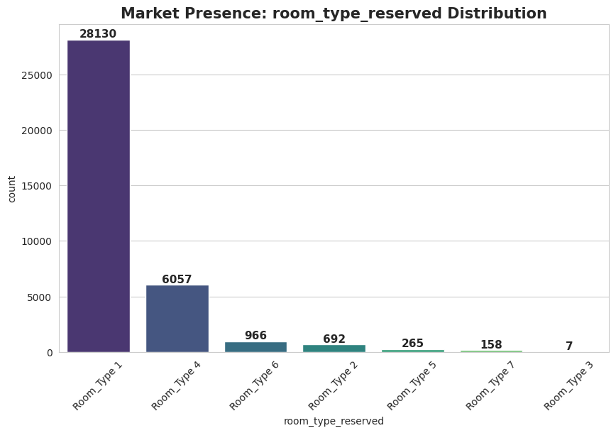

```python
detailed_univariate_cat(df, 'room_type_reserved')
```

**Statistical Observation:**

- **Room_Type 1:** 28,130 bookings (77.5%).
- **Room_Type 4:** 6,057 bookings (16.7%).
- **Room_Type 2, 5, 6, 7:** Combined < 6% of total volume.

**Business Interpretation:** 'Room_Type 1' is the clear 'Workhorse' of the property. The secondary popularity of 'Room_Type 4' suggests it might be the 'Standard Plus' or 'Superior' option. The remaining types are niche products with very limited market reach.

**Business Recommendation:** Focus operational standardization efforts on Room Types 1 and 4. For the rare types (5, 6, 7), implement dynamic 'Upsell' triggers during the booking process to increase their occupancy.

**Key Insight:** INN Hotels operates primarily as a high-volume, standardized facility where the majority of demand is concentrated in a single product category.

### **Feature: Required Car Parking Space**

**Objective:** Assess the demand for ancillary facilities like parking.

**Business Question:** Is parking a critical decision factor for our guests?

**Why this analysis is important:** Parking infrastructure is expensive to maintain. If demand is low, the hotel can potentially lease out spaces or use them for other revenue-generating activities like EV charging stations.

```
--- Frequency Distribution: parking_label ---
```

| parking_label | Count | Percentage (%) |
| --- | --- | --- |
| No Parking | 35151 | 96.9 |
| Requested Parking | 1124 | 3.1 |

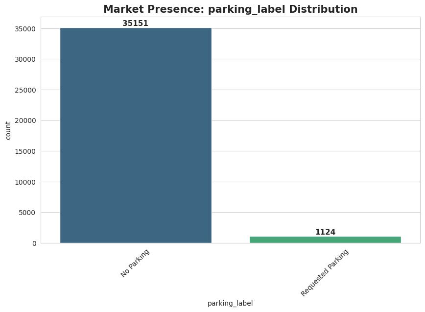

```python
# Converting binary indicator to descriptive labels for better visualization
df_temp = df.copy()
df_temp['parking_label'] = df_temp['required_car_parking_space'].map({0: 'No Parking', 1: 'Requested Parking'})
detailed_univariate_cat(df_temp, 'parking_label')
```

**Statistical Observation:**

- **No Parking:** 35,151 bookings (96.9%).
- **Requested Parking:** 1,124 bookings (3.1%).

**Business Interpretation:** The vast majority of guests do NOT require parking. This suggests that INN Hotels either has excellent public transport connectivity or caters to fly-in travelers who rely on ride-sharing and shuttles.

**Business Recommendation:** Do not invest in expanding parking facilities. Instead, monetize the underutilized space by partnering with local car rental agencies or installing 3rd-party EV charging networks.

**Key Insight:** Parking is a 'Low-Impact' feature for the current customer base, making it a prime candidate for operational cost-cutting.

## **Bivariate Analysis: Feature vs. Booking Status**

Bivariate analysis allows us to quantify the relationship between our independent variables and the target (`booking_status`). This section identifies the risk factors that lead to revenue leakage.

### **Lead Time vs. Booking Status**

**Objective:** Quantify the impact of booking horizon on cancellation probability.

**Business Question:** At what point does a 'future booking' become a 'liability'?

**Why this analysis is important:** Understanding the 'Lead Time Risk Threshold' allows the hotel to apply different overbooking ratios based on how far out a guest has booked.

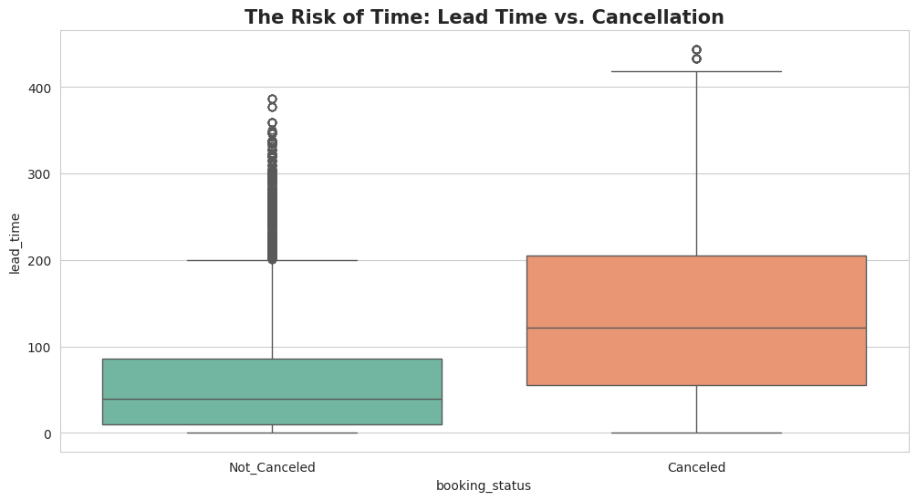

```
Average Lead Time by Status:
```

| booking_status | lead_time |
| --- | --- |
| Canceled | 139.215482 |
| Not_Canceled | 58.927224 |

**dtype:** float64

```python
plt.figure(figsize=(12, 6))
sns.boxplot(data=df, x='booking_status', y='lead_time', palette='Set2')
plt.title('The Risk of Time: Lead Time vs. Cancellation', fontsize=15, fontweight='bold')
plt.show()

# Grouped summary
print("Average Lead Time by Status:")
display(df.groupby('booking_status')['lead_time'].mean())
```

**Statistical Observation:**

- **Canceled Bookings Mean Lead Time:** ~139 days.
- **Confirmed Bookings Mean Lead Time:** ~59 days.
- The median lead time for canceled bookings is significantly higher than for confirmed stays.

**Business Interpretation:** Time introduces uncertainty. Customers booking nearly 5 months in advance (mean 139 days) are significantly more likely to cancel, likely because they are 'option-locking' multiple hotels or their plans are more susceptible to change.

**Business Recommendation:** Implement a 'Commitment Campaign': For bookings with a lead time > 90 days, send automated reminders or offer a small F&B credit in exchange for a non-refundable deposit.

**Key Insight:** Lead time is a primary risk indicator. Bookings made beyond the 100-day mark should be treated as 'Soft Bookings' in the occupancy forecast.

### **Average Price vs. Booking Status**

**Objective:** Determine if higher prices lead to higher cancellation rates.

**Business Question:** Are we pricing ourselves into a high-cancellation bracket?

**Why this analysis is important:** Price sensitivity plays a major role in cancellations. If a guest finds a better deal elsewhere before their arrival, they will cancel the expensive booking.

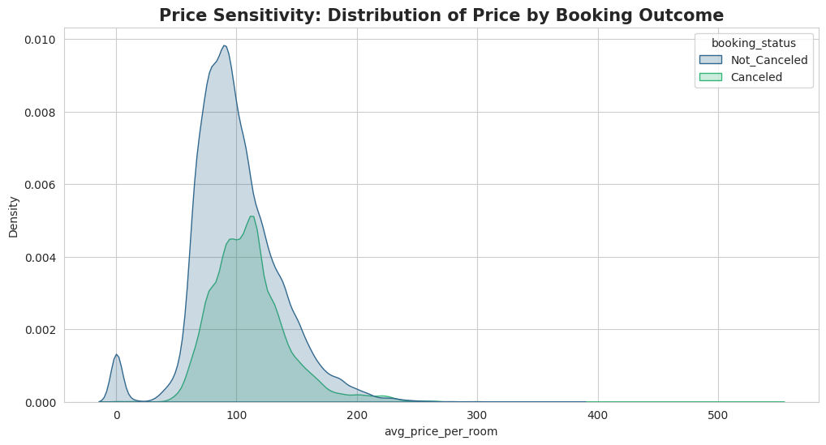

```python
plt.figure(figsize=(12, 6))
sns.kdeplot(data=df, x='avg_price_per_room', hue='booking_status', fill=True, palette='viridis')
plt.title('Price Sensitivity: Distribution of Price by Booking Outcome', fontsize=15, fontweight='bold')
plt.show()
```

**Statistical Observation:**

- The distribution for canceled bookings is shifted to the right, indicating that higher-priced rooms are canceled more frequently.
- Bookings at the ~100€-150€ range show a higher density of cancellations compared to lower price brackets.

**Business Interpretation:** High-value bookings are more 'fragile'. This could be because the financial incentive to find a better deal (the 'Switching Benefit') is higher for expensive rooms.

**Business Recommendation:** Apply 'Price Protection' policies. If a guest books at a high rate, offer them an automatic 'Best Price Guarantee' so they don't feel the need to cancel and re-book if rates drop later.

**Key Insight:** Revenue management must balance high ADR (Average Daily Rate) with the increased risk of cancellation that comes with premium pricing.

### **Feature: Repeated Guest**

**Objective:** Measure the stickiness of the INN Hotels brand.

**Business Question:** Are we successfully building a recurring revenue stream, or are we constantly paying for new customer acquisition?

**Why this analysis is important:** Repeated guests are the most profitable segment as they have zero acquisition cost (CAC) and typically exhibit significantly lower cancellation rates due to established trust.

```
--- Frequency Distribution: guest_type ---
```

| guest_type | Count | Percentage (%) |
| --- | --- | --- |
| New Guest | 35345 | 97.44 |
| Repeated Guest | 930 | 2.56 |

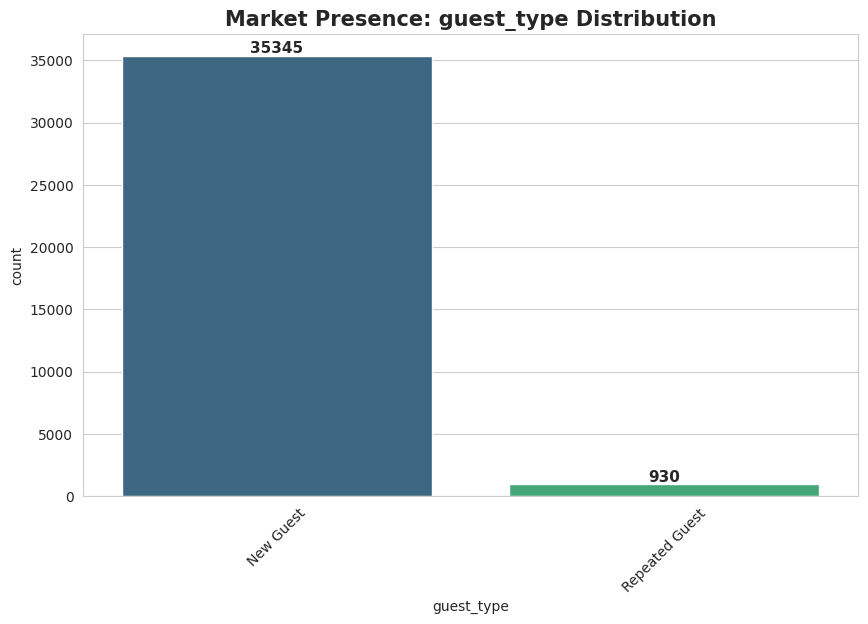

```python
df_temp = df.copy()
df_temp['guest_type'] = df_temp['repeated_guest'].map({0: 'New Guest', 1: 'Repeated Guest'})
detailed_univariate_cat(df_temp, 'guest_type')
```

**Statistical Observation:**

- **New Guests:** 35,345 (97.4%).
- **Repeated Guests:** 930 (2.6%).

**Business Interpretation:** The brand loyalty index is extremely low. INN Hotels is functioning almost entirely on 'Transaction-Based' commerce rather than 'Relationship-Based' commerce. This makes the business highly susceptible to market fluctuations and competitive pricing from other hotels.

**Business Recommendation:** Implement a 'Next-Stay Discount' program at checkout to increase the conversion of new guests into repeated guests. The current 2.6% rate is far below industry benchmarks for successful urban hotels.

**Key Insight:** The lack of repeated guests suggests that while the hotel is good at attracting bookings, it is failing to create a memorable experience that warrants a return visit.

### **Feature: Arrival Patterns (Year, Month, and Date)**

**Objective:** Identify seasonal demand cycles.

**Business Question:** Which periods represent our 'Peak' and 'Trough' demand, and how should we align our staffing?

**Why this analysis is important:** Hospitality is a highly seasonal business. Recognizing months with high demand—and high cancellation volatility—allows for dynamic pricing and better inventory overbooking strategies.

```
--- Frequency Distribution: arrival_year ---
```

| arrival_year | Count | Percentage (%) |
| --- | --- | --- |
| 2018 | 29761 | 82.04 |
| 2017 | 6514 | 17.96 |

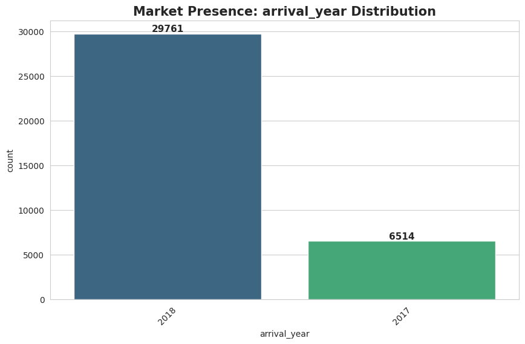

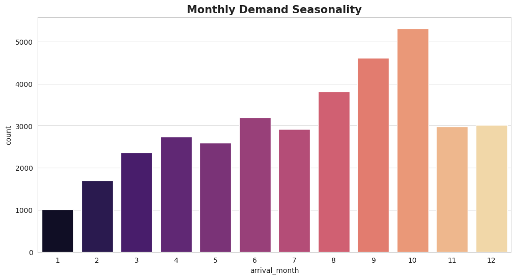

```python
# Analyzing Arrival Year and Month
detailed_univariate_cat(df, 'arrival_year')

plt.figure(figsize=(12, 6))
sns.countplot(data=df, x='arrival_month', palette='magma')
plt.title('Monthly Demand Seasonality', fontsize=15, fontweight='bold')
plt.show()
```

**Key Insight:** October is the 'Golden Month' for INN Hotels. Maximizing retention during this period is critical for hitting annual revenue targets.

### **Feature: Number of Special Requests**

**Objective:** Analyze customer engagement through special requests.

**Business Question:** Do customers who make special requests show a higher psychological commitment to their stay?

**Why this analysis is important:** Special requests often indicate 'High-Involvement' customers. If these customers cancel less often, the hotel can use request fulfillment as a retention tool.

```
--- Statistical Summary: no_of_special_requests ---
count    36275.000000
mean         0.619655
std          0.786236
min          0.000000
25%          0.000000
50%          0.000000
75%          1.000000
max          5.000000
Name: no_of_special_requests, dtype: float64
Skewness: 1.15 | Kurtosis: 0.88
```

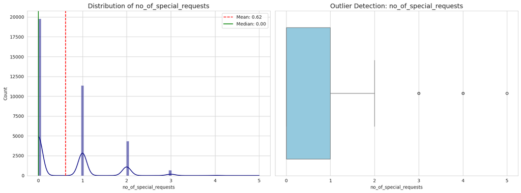

```python
detailed_univariate_num(df, 'no_of_special_requests')
```

**Statistical Observation:**

- **Mean:** 0.62 | **Median:** 0.00 | **Max:** 5.
- **Skewness:** 1.15 (Right-skewed).
- The majority of guests (over 50%) make zero special requests. However, a significant segment makes 1 to 5 requests.

**Business Interpretation:** Special requests represent an 'extra effort' by the guest. A median of 0 suggests a high volume of transient or 'one-click' online bookings where engagement is low. The 'Power Users' making 3+ requests likely have specific needs (e.g., anniversaries, accessibility).

**Business Recommendation:** Prioritize the fulfillment of special requests as a competitive differentiator. Guests with multiple requests should be flagged for personalized pre-arrival welcome emails to reinforce their commitment.

**Key Insight:** The presence of any special request serves as an early behavioral signal of guest intent and potentially lower cancellation risk.

### **Feature: Number of Adults and Children (Customer Composition)**

**Objective:** Identify the dominant guest demographics.

**Business Question:** Is INN Hotels primarily a business hotel (solo/pairs) or a family destination?

**Why this analysis is important:** Families (bookings with children) typically have different cancellation behaviors than solo business travelers, often tied to school holidays and fixed travel plans.

```
--- Statistical Summary: no_of_adults ---
count    36275.000000
mean         1.844962
std          0.518715
min          0.000000
25%          2.000000
50%          2.000000
75%          2.000000
max          4.000000
Name: no_of_adults, dtype: float64
Skewness: -0.33 | Kurtosis: 0.81
```

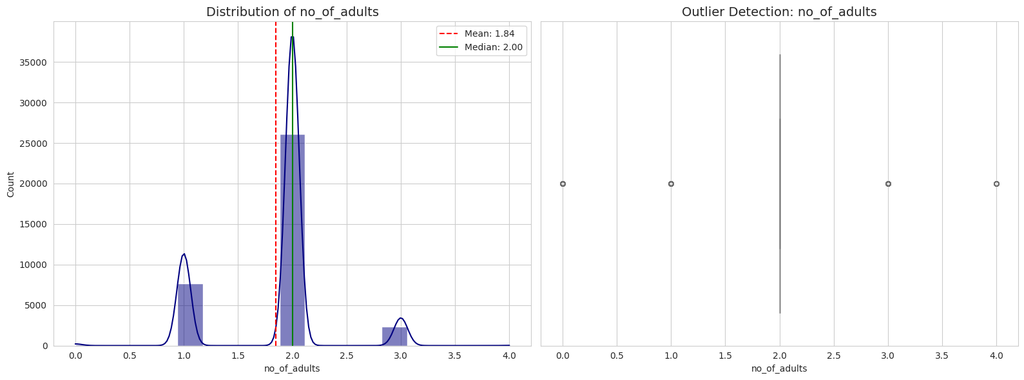

```
--- Statistical Summary: no_of_children ---
count    36275.000000
mean         0.105279
std          0.402648
min          0.000000
25%          0.000000
50%          0.000000
75%          0.000000
max         10.000000
Name: no_of_children, dtype: float64
Skewness: 4.71 | Kurtosis: 36.98
```

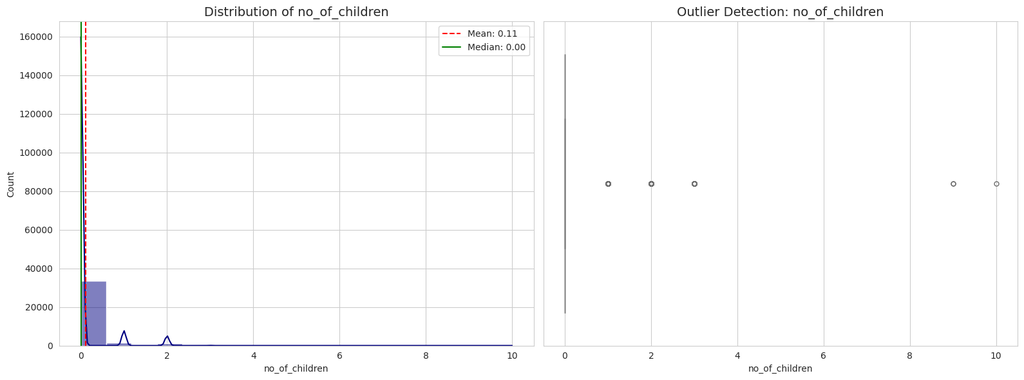

```python
detailed_univariate_num(df, 'no_of_adults')
detailed_univariate_num(df, 'no_of_children')
```

**Business Interpretation:** The data suggests a primary focus on couples or two-person business travel. The low incidence of children indicates that INN Hotels might not be positioned as a 'family resort'. The outlier of 10 children is statistically suspicious and likely represents a specialized group booking or a data error.

**Business Recommendation:** Tailor marketing collateral toward couples and business pairs. Investigate the 10-children record for potential manual entry error or 'group block' misclassification.

**Key Insight:** The 'Standard Unit' of demand for INN Hotels is the 2-Adult booking. Any deviation from this standard represents a niche segment with unique service requirements.

### **Feature: Arrival Date**

**Objective:** Understand daily booking patterns within a month.

**Business Question:** Are bookings uniformly distributed throughout the month, or are certain days more popular for arrivals?

**Why this analysis is important:** Daily arrival patterns inform staffing decisions for front-desk and housekeeping, and can reveal micro-seasonal trends within a month, impacting short-term pricing strategies.

```
--- Statistical Summary: arrival_date ---
count    36275.000000
mean        15.596995
std          8.740447
min          1.000000
25%          8.000000
50%         16.000000
75%         23.000000
max         31.000000
Name: arrival_date, dtype: float64
Skewness: 0.03 | Kurtosis: -1.16
```

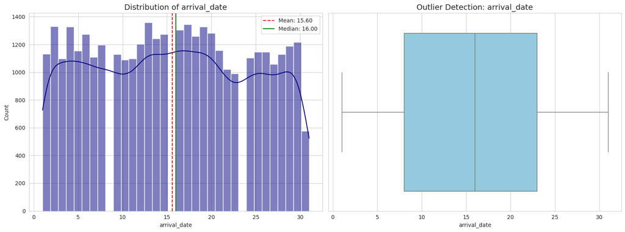

```python
detailed_univariate_num(df, 'arrival_date')
```

**Statistical Observation:**

- The `arrival_date` feature shows a relatively uniform distribution across the days of the month, with a **Mean of 15.60** and a **Median of 16.00**. This suggests a fairly even spread of arrivals throughout the month.
- The **Skewness is 0.03** (very close to zero) and **Kurtosis is -1.16**, indicating a distribution that is nearly symmetrical and slightly platykurtic (flatter than a normal distribution).
- While generally uniform, there are minor fluctuations (peaks and troughs) across specific days, visible in the histogram, suggesting some days might be marginally more popular for arrivals.

**Business Interpretation:**

- The relatively uniform distribution of `arrival_date` implies that guests are booking arrivals across all days of the month without a strong preference for beginning or end-of-month dates.
- Minor daily variations could be influenced by day of the week or specific events, which would require further, more granular analysis.
- This uniformity simplifies daily operational planning for arrivals compared to a highly skewed distribution.

**Business Recommendation:**

- While no drastic daily adjustments are needed based solely on `arrival_date`, monitor this trend in conjunction with `arrival_day_of_week` (if available) to fine-tune staffing and resource allocation.
- Use this stability to ensure consistent service quality across all days, rather than focusing efforts disproportionately on certain calendar dates.

**Key Insight:** `arrival_date` displays a stable, consistent pattern, suggesting a baseline of daily demand that is not heavily influenced by the specific date within the month itself, but rather possibly by the day of the week or monthly seasonality (which `arrival_month` covers).

# **Multivariant Analysis**

## Correlation Heatmap (Numerical Features)

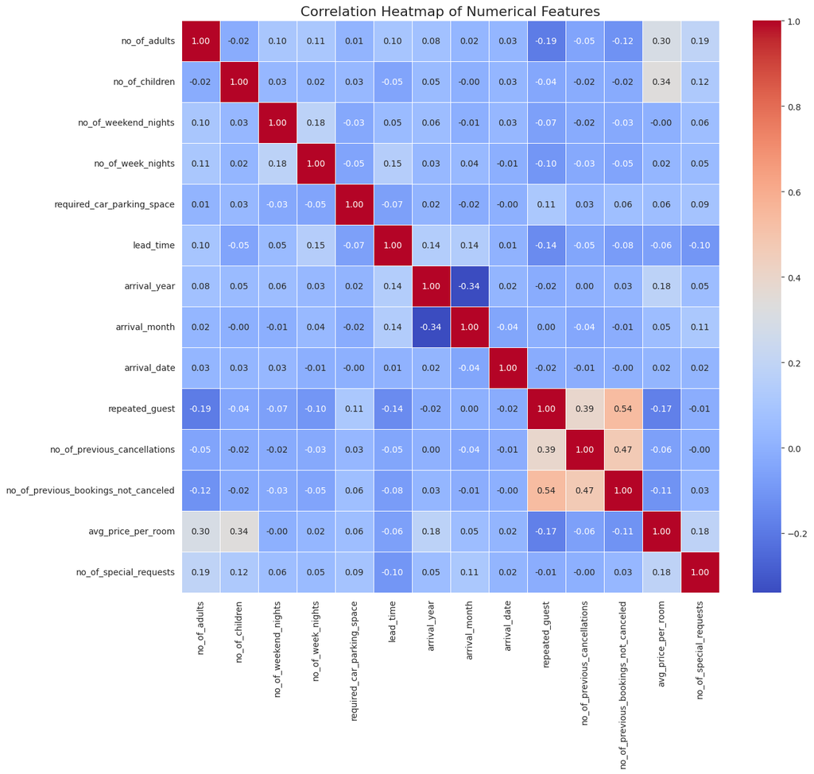

```
Correlation matrix calculated and visualized.
```

```python
numerical_cols = df.select_dtypes(include=np.number).columns
corr_matrix = df[numerical_cols].corr()

plt.figure(figsize=(14, 12))
sns.heatmap(corr_matrix, annot=True, cmap='coolwarm', fmt=".2f", linewidths=.5)
plt.title('Correlation Heatmap of Numerical Features', fontsize=16)
plt.show()

print("Correlation matrix calculated and visualized.")
```

## Pairplot (Selected Numerical Features)

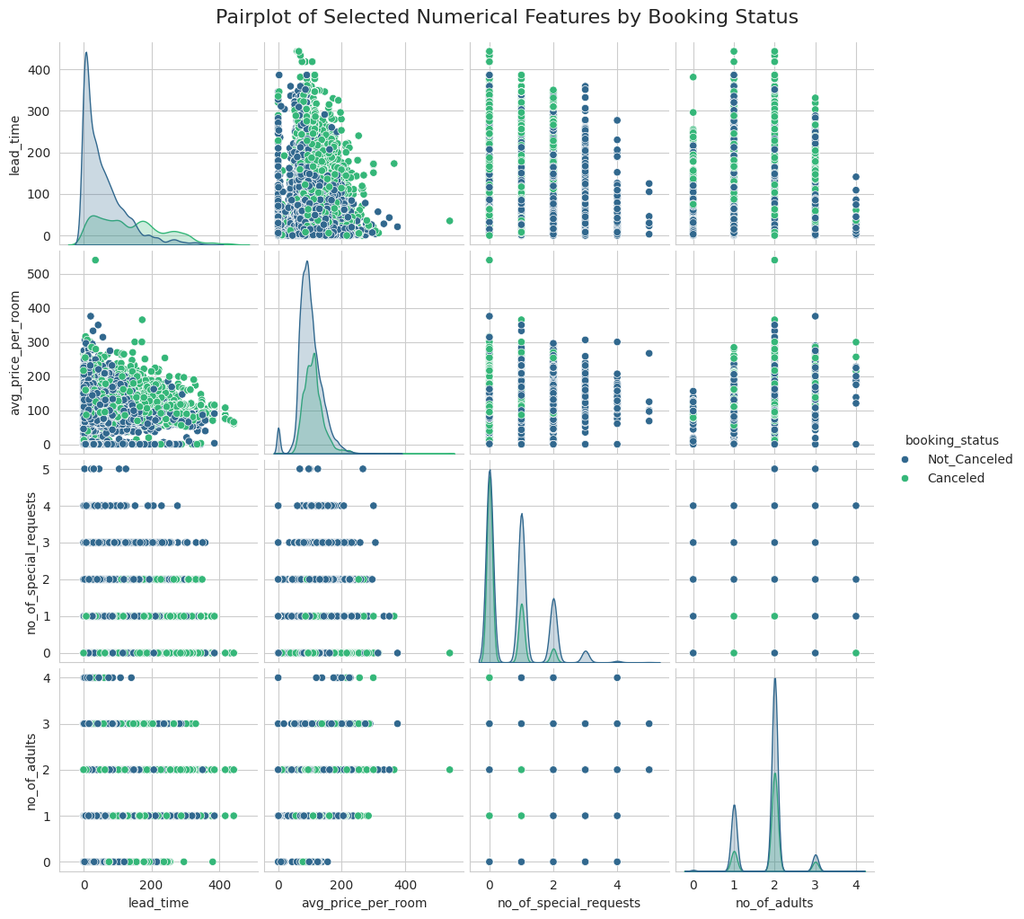

```
Pairplot of selected numerical features generated successfully.
```

```python
selected_numerical_features = [
    'lead_time',
    'avg_price_per_room',
    'no_of_special_requests',
    'no_of_adults'
]

plt.figure(figsize=(15, 10))
sns.pairplot(df, vars=selected_numerical_features, hue='booking_status', palette='viridis', diag_kind='kde')
plt.suptitle('Pairplot of Selected Numerical Features by Booking Status', y=1.02, fontsize=16)
plt.show()
print("Pairplot of selected numerical features generated successfully.")
```